Introducción Exploración de datos Preguntas y Propuesta Experimento 1 [hito2] Experimento 1 [hito3] Experimento 2 Experimento 3 Experimento 4 Experimento 5 Experimento 6 Contribución

# ¿Existen palabras o modismos que se repliquen entre twitts de una misma zona geográfica?

```python
import os.path as path
import pandas as pd
import os
import datetime
import numpy as np
import calendar
import matplotlib.pyplot as plt
import nltk
import wordcloud
nltk.download('punkt')
```

```
True
```

# Carga de datos

Se cargaron los datos pero se usan solamente el tweet y la clase

```python
data = pd.read_csv("tweets_chile_geolocalizados2.csv", sep='\t', names=['idTweet', 'idUser','created_at','tweet','latitud','longitude','class'])
```

Obteniendo el siguiente resultado:

```python
data
```

|  | idTweet | idUser | created_at | tweet | latitud | longitude | class |
| --- | --- | --- | --- | --- | --- | --- | --- |
| 0 | 351490338654916608 | 73787280 | 2013-07-01 00:00:01 | “@naraback: Si bachelet fuera flaca, con qué l... | -33.2615 | -70.6297 | RM |
| 1 | 351490339107901442 | 325370754 | 2013-07-01 00:00:01 | Si gana Longueira, la mínima posibilidad de ga... | -32.9544 | -71.5317 | centro |
| 2 | 351490342996033536 | 96595015 | 2013-07-01 00:00:02 | BRASIL CAMPEÓN MUNDIAL !!!! Gana a España 3-0 | -33.4395 | -70.6026 | RM |
| 3 | 351490358078742532 | 172096924 | 2013-07-01 00:00:06 | Denuevo la Bachelet... porque lo chilenos no a... | -33.4133 | -70.5777 | RM |
| 4 | 351490399686230016 | 115070990 | 2013-07-01 00:00:16 | Esta que arde la cosa entre Allamand y Longuei... | -33.4872 | -70.6531 | RM |
| ... | ... | ... | ... | ... | ... | ... | ... |
| 9752490 | 870066396109078528 | 123745861 | 2017-05-31 23:56:08 | Mi doctor y su mala idea de tener su consulta ... | -33.4093 | -70.5732 | RM |
| 9752491 | 870066468024725505 | 119277399 | 2017-05-31 23:56:25 | Once romántica solitaria.. llenándome de energ... | -33.4374 | -70.6334 | RM |
| 9752492 | 870066525520224256 | 126125055 | 2017-05-31 23:56:39 | Un hermoso tejido que me hizo mi madre para mi... | -33.6081 | -70.6952 | RM |
| 9752493 | 870066808547454976 | 68747705 | 2017-05-31 23:57:46 | Holis!!! kattta_monroy 🙈🙊 #quemaneradereirnos ... | -38.4167 | -72.3833 | sur |
| 9752494 | 870067310605869056 | 372267677 | 2017-05-31 23:59:46 | Después de un largo día de prensa en Stgo junt... | -33.4296 | -70.6210 | RM |

9752495 rows × 7 columns

```python
from nltk.tokenize import word_tokenize #Tokenizer
from nltk.corpus import stopwords #Stopwords
from string import punctuation
from collections import defaultdict

#Letras en mayúsculas
upper = 'ABCDEFGHIJKLMNOPQRSTUVWXYZ'

#Stopwords en español
spanish_stopwords = stopwords.words('spanish')

#caracteres especiales (puntuación, exclamación, etc)
special_chars = list(punctuation)


#Se añaden más y números
special_chars.extend(['¿', '¡','“','”','//','/'])
special_chars.extend(['0','1','2','3','4','5','6','7','8','9'])
```

# Frecuencia de palabras

```python
#Diccionarios para almacenar distintas frecuencias
rm_freq = defaultdict(int) #frecuencia de región metropolitana
nor_freq = defaultdict(int) #frecuencia de zona norte
cen_freq = defaultdict(int) #frecuencia de centro
sur_freq = defaultdict(int) #frecuencia de sur

gen_freq = defaultdict(int) #frecuencia en todas la zonas incluídas stopwords

no_sw_freq = defaultdict(int) #frecuencia sin considerar stopwords

p_n_freq = defaultdict(int) #frecuencia de sustantivos propios

in_all = defaultdict(int)

i = 0

#Iteración por todas las filas del  dataframe
for _,row in data.iterrows():
    i += 1
    if not i%10000:
        print(f'{i} tweets read') #contador del procesamiento
    zona = row['class']
    tweet = ''.join([c for c in row['tweet'] if c not in special_chars]) #no consideramos caracteres especiales
    for token in word_tokenize(tweet): #por cada token del tweet
        if not token.lower() in spanish_stopwords: #es el token stopword?
            #Sumamos uno en dict de frecuencia no stopwords
            no_sw_freq[token] += 1
            #Sumamos uno a la aparición del token según la zona
            if zona == 'RM':
                rm_freq[token] += 1
            elif zona == 'norte':
                nor_freq[token] += 1
            elif zona == 'centro':
                cen_freq[token] += 1
            else:
                sur_freq[token] += 1

            if rm_freq[token] and nor_freq[token] and cen_freq[token] and sur_freq[token]:
                in_all[token] = rm_freq[token] + nor_freq[token] + cen_freq[token] + sur_freq[token]

            if token[0] in upper: #Vemos si es sustantivo propio
                p_n_freq[token] += 1

        #Lo añadimos siempre al dict general
        gen_freq[token] += 1
```

```
10000 tweets read
20000 tweets read
...
9740000 tweets read
9750000 tweets read
```

# Resultados

### Frecuencia sin considerar stopwords

```python
no_stopwords_dict = dict(sorted(no_sw_freq.items(), key=lambda item: item[1], reverse=True))
```

### Frecuencia con stopwords

```python
with_stop_words_dict = dict(sorted(gen_freq.items(), key=lambda item: item[1], reverse=True))
```

### Frecuencia Región Metropolitana

```python
rm_dict = dict(sorted(rm_freq.items(), key=lambda item: item[1], reverse=True))
```

### Frecuencia zona norte

```python
north_dict = dict(sorted(nor_freq.items(), key=lambda item: item[1], reverse=True))
```

### Frecuencia zona Centro

```python
center_dict = dict(sorted(cen_freq.items(), key=lambda item: item[1], reverse=True))
```

### Frecuencia zona sur

```python
south_dict = dict(sorted(sur_freq.items(), key=lambda item: item[1], reverse=True))
```

### Frecuencia sustantivos propios

```python
proper_nouns = dict(sorted(p_n_freq.items(), key=lambda item: item[1], reverse=True))
```

# Hashtags

Se ve la frecuencia de los hashtags, de manera general y por zonas.

```python
rm_hash = defaultdict(int)
nor_hash = defaultdict(int)
cen_hash = defaultdict(int)
sur_hash = defaultdict(int)

gen_hash = defaultdict(int)

i = 0
for _,row in data.iterrows():
    i += 1
    if not i%10000:
        print(f"{i} tweets read")
    zona = row['class']
    if '#' in row['tweet']: #Está el caracter de hashtag?
        text = row['tweet'].replace('#','XXXhashtagXXX') #Lo cambiamos por un string especial para no tener problemas al tokenizar
        tokens = word_tokenize(text)
        for token in tokens:
            if 'XXXhashtagXXX' in token: #Si está el el string especial
                gen_hash[token.replace('XXXhashtagXXX','#')] += 1 #Cambiamos el string especial por # nuevamente
                if zona == 'RM':
                    rm_hash[token.replace('XXXhashtagXXX','#')] += 1
                elif zona == 'norte':
                    nor_hash[token.replace('XXXhashtagXXX','#')] += 1
                elif zona == 'centro':
                    cen_hash[token.replace('XXXhashtagXXX','#')] += 1
                else:
                    sur_hash[token.replace('XXXhashtagXXX','#')] += 1
```

```
10000 tweets read
20000 tweets read
...
9740000 tweets read
9750000 tweets read
```

# Resultados

### Frecuencia de hashtags general

```python
dict(sorted(gen_hash.items(), key=lambda item: item[1], reverse=True))
```

```
{'#Chile': 30769,
  '#chile': 29794,
  '#instachile': 26222,
  '#Santiago': 14029,
  '#Antofagasta': 12801,
  '#VamosChile': 10247,
  '#santiago': 10239,
  '#VamosLaU': 9780,
  '#AmorAPrueba': 9475,
  '#love': 9145,
  '#selfie': 8793,
  '#': 8747,
  '#instalike': 8174,
  '#Temuco': 8162,
  '#ColoColo': 8154,
  '#iquique': 7994,
  '#CHI': 7529,
  '#Los80': 7148,
  '#LosCruzados': 7077,
  '#friends': 7002,
  ...}
```

### Frecuencia de hashtags Región Metropolitana

```python
dict(sorted(rm_hash.items(), key=lambda item: item[1], reverse=True))
```

```
{'#Chile': 14167,
  '#chile': 13085,
  '#Santiago': 12680,
  '#instachile': 11416,
  '#santiago': 9377,
  '#VamosLaU': 5215,
  '#VamosChile': 5068,
  '#ColoColo': 4613,
  '#LosCruzados': 4300,
  '#love': 4266,
  '#': 4019,
  '#CHI': 3909,
  '#selfie': 3753,
  '#Los80': 3710,
  '#eso': 3690,
  '#me': 3426,
  '#fb': 3416,
  '#MiNombreEs': 3407,
  '#VamosColoColo': 3402,
  '#instalike': 3208,
  ...}
```

### Frecuencia de hashtags zona norte

```python
dict(sorted(nor_hash.items(), key=lambda item: item[1], reverse=True))
```

```
{'#Antofagasta': 12106,
  '#iquique': 7537,
  '#Iquique': 6259,
  '#Chile': 3902,
  '#antofagasta': 3876,
  '#LaSerena': 3833,
  '#chile': 3722,
  '#laserena': 3016,
  '#instachile': 2388,
  '#Coquimbo': 1924,
  '#Arica': 1636,
  '#AmorAPrueba': 1529,
  '#coquimbo': 1476,
  '#arica': 1170,
  '#Copiapó': 1169,
  '#Ovalle': 905,
  '#selfie': 897,
  '#': 889,
  '#VamosChile': 869,
  '#LasMilyUnaNoches': 859,
  ...}
```

### Frecuencia de hashtags zona centro

```python
dict(sorted(cen_hash.items(), key=lambda item: item[1], reverse=True))
```

```
{'#instachile': 9163,
  '#chile': 8975,
  '#Chile': 8635,
  '#AmorAPrueba': 3608,
  '#VamosChile': 3460,
  '#viñadelmar': 3379,
  '#selfie': 3245,
  '#love': 3189,
  '#instalike': 3134,
  '#': 3040,
  '#VamosLaU': 2937,
  '#valparaiso': 2930,
  '#playa': 2668,
  '#friends': 2572,
  '#viña': 2457,
  '#Los80': 2338,
  '#CHI': 2318,
  '#me': 2311,
  '#Talca': 2311,
  '#summer': 2199,
  ...}
```

### Frecuencia de hashtags zona sur

```python
dict(sorted(sur_hash.items(), key=lambda item: item[1], reverse=True))
```

```
{'#Temuco': 7888,
  '#valdiviacl': 5134,
  '#Chile': 4065,
  '#chile': 4012,
  '#instachile': 3255,
  '#temuco': 2241,
  '#puq': 2150,
  '#puertomontt': 2145,
  '#PuertoMontt': 2079,
  '#pucon': 1706,
  '#Osorno': 1676,
  '#Valdivia': 1314,
  '#Valdiviacl': 1241,
  '#valdivia': 1209,
  '#vacaciones': 1164,
  '#AmorAPrueba': 1145,
  '#osorno': 1103,
  '#chiloe': 1065,
  '#instalike': 1012,
  '#fb': 970,
  ...}
```

# Palabras más frecuentes en un lugar

```python
nor_freq_filtered = defaultdict(int)
cen_freq_filtered = defaultdict(int)
sur_freq_filtered = defaultdict(int)
rm_freq_filtered = defaultdict(int)



for k, v in nor_freq.items():
    if v > cen_freq[k] and v > rm_freq[k] and v > sur_freq[k]:
        nor_freq_filtered[k] = nor_freq[k]

for k, v in cen_freq.items():
    if v > nor_freq[k] and v > rm_freq[k] and v > sur_freq[k]:
        cen_freq_filtered[k] = cen_freq[k]

for k, v in sur_freq.items():
    if v > cen_freq[k] and v > rm_freq[k] and v > nor_freq[k]:
        sur_freq_filtered[k] = sur_freq[k]

for k, v in rm_freq.items():
    if v > cen_freq[k] and v > nor_freq[k] and v > sur_freq[k]:
        rm_freq_filtered[k] = rm_freq[k]
```

## Mayor frecuencia en zona norte

```python
most_north = dict(sorted(nor_freq_filtered.items(), key=lambda item: item[1], reverse=True))
most_north
```

```
{'Antofagasta': 52454,
  'Coquimbo': 34024,
  'Serena': 32918,
  'Iquique': 29522,
  'Arica': 12100,
  'Atacama': 11416,
  'iquique': 9940,
  'Tarapacá': 9846,
  'Copiapó': 8891,
  'Ovalle': 5930,
  'antofagasta': 5643,
  'LaSerenaChile': 4170,
  'Elqui': 3990,
  'LaSerena': 3908,
  'serena': 3602,
  'laserena': 3097,
  'Copiapo': 3035,
  'ANF': 2848,
  'Cavancha': 2825,
  'coquimbo': 2809,
  ...}
```

## Mayor frecuencia en zona centro

```python
most_center = dict(sorted(cen_freq_filtered.items(), key=lambda item: item[1], reverse=True))
most_center
```

```
{'Valparaíso': 129962,
  'Viña': 98489,
  'Mar': 81003,
  'Concepción': 52689,
  'Biobío': 37668,
  'Talca': 32278,
  'Playa': 27640,
  'Valparaiso': 21577,
  'biobio': 17016,
  'Maule': 16729,
  'Rancagua': 16666,
  'Villa': 16227,
  'Terminal': 15836,
  'viña': 15433,
  'Chillán': 14122,
  'Pedro': 14092,
  'Talcahuano': 13983,
  'mar': 13501,
  'Sur': 12842,
  'playa': 12567,
  ...}
```

## Mayor frecuencia en zona sur

```python
most_south = dict(sorted(sur_freq_filtered.items(), key=lambda item: item[1], reverse=True))
most_south
```

```
{'Temuco': 43113,
  'Puerto': 39040,
  'Lagos': 29677,
  'Araucanía': 28317,
  'Montt': 22523,
  'Valdivia': 21205,
  'Osorno': 13869,
  'Pucón': 11786,
  'Varas': 10451,
  'Lago': 7486,
  'Ríos': 7337,
  'Villarrica': 6803,
  'Castro': 6531,
  'valdiviacl': 5340,
  'Rios': 5245,
  'Pucon': 5049,
  'Frutillar': 4410,
  'Coyhaique': 4200,
  'Magallanes': 4192,
  'Arenas': 4161,
  ...}
```

## Mayor frecuencia en región metropolitana

```python
most_rm = dict(sorted(rm_freq_filtered.items(), key=lambda item: item[1], reverse=True))
most_rm
```

```
{'Metropolitana': 371385,
  'Región': 355320,
  'Santiago': 342705,
  'in': 306122,
  'at': 295630,
  'Im': 238846,
  'Chile': 183511,
  'w': 170798,
  'q': 165706,
  'si': 136314,
  'día': 128504,
  'others': 120544,
  'B': 96982,
  'mejor': 94558,
  'mas': 89251,
  'Condes': 84011,
  'hoy': 83487,
  'San': 80180,
  'Providencia': 68811,
  'ahora': 68009,
  ...}
```

# Palabras que están sólo en una zona

```python
nor_freq_only = defaultdict(int)
cen_freq_only = defaultdict(int)
sur_freq_only = defaultdict(int)
rm_freq_only = defaultdict(int)



for k, v in nor_freq.items():
    if not (cen_freq[k] or rm_freq[k] or sur_freq[k]):
        nor_freq_only[k] = v

for k, v in cen_freq.items():
    if not (nor_freq[k] or rm_freq[k] or sur_freq[k]):
        cen_freq_only[k] = v

for k, v in sur_freq.items():
    if not (cen_freq[k] or rm_freq[k] or nor_freq[k]):
        sur_freq_only[k] = v

for k, v in rm_freq.items():
    if not (cen_freq[k] or nor_freq[k] or sur_freq[k]):
        rm_freq_only[k] = v
```

## Sólo en el norte

```python
only_north = dict(sorted(nor_freq_only.items(), key=lambda item: item[1], reverse=True))
only_north
```

```
{'Antifagasta': 451,
  'Huayquique': 374,
  'BelloPampa': 369,
  'cabpampa': 344,
  'coquimbocl': 342,
  'TalosPrincipleLive': 301,
  'Trevizan': 267,
  'GardenBar': 256,
  'emelatsos': 230,
  'cumpleaños🎂🎁': 222,
  'Amoooo😘😍💕': 222,
  'fmmasarica': 220,
  'Altovalsol': 194,
  'Seriche': 194,
  'Coquimbocl': 193,
  'aeroiquique': 189,
  'Okoru': 185,
  'aeroantofagasta': 174,
  '▃▃▃▃▃▃▃▃▃▃▃▃▃▃▃▃▃▃▃▃': 170,
  '✽LocaciónAntofagasta': 170,
  ...}
```

## Sólo en el centro

```python
only_center = dict(sorted(cen_freq_only.items(), key=lambda item: item[1], reverse=True))
only_center
```

```
{'mundotecvregion': 690,
  'sportalifechile': 662,
  'mallcentroconce': 601,
  'uvmcl': 551,
  'PegasLosAngeles': 533,
  'panoramaudec': 528,
  'Botania': 507,
  'BoulevardMarina': 461,
  'AutoCheckin': 442,
  'ibnux': 442,
  '★cumplan': 441,
  'mjsconcepcion': 408,
  'httptcoeBiypwwuym': 387,
  'saryurrutia': 374,
  'nicolasuc': 374,
  'fuanavideño': 372,
  'FuenteAlemanaCl': 347,
  'virginiogomez': 330,
  'meroboelcorazon': 324,
  'Michelitoss': 323,
  ...}
```

## Sólo en el sur

```python
only_south = dict(sorted(sur_freq_only.items(), key=lambda item: item[1], reverse=True))
only_south
```

```
{'httptcocqFowIVvZ': 1409,
  'httpstcocqFowIDVs': 748,
  'Baechler': 359,
  'enjoypucon': 338,
  'aeropuntaarenas': 297,
  'Rí': 263,
  'httptcocqFowIEsX': 263,
  'ufrontera': 261,
  'Guarisapos': 256,
  'solcharrua': 253,
  'Jesiicenturion': 245,
  'Mocopulli': 238,
  'BomberosCoyhaique': 235,
  'Cañal': 221,
  'httptcocqFowJd': 203,
  'Edelaysen': 186,
  'httptcongzcSvYx': 179,
  'httpstcocqFowIVvZ': 179,
  'mundolider': 173,
  'AquaRent': 170,
  ...}
```

## Sólo en región metropolitana

```python
only_rm = dict(sorted(rm_freq_only.items(), key=lambda item: item[1], reverse=True))
only_rm
```

```
{'gimnasiosenergy': 3676,
  'hardcandychile': 1482,
  'YoVoyaDemiConUniversal': 1466,
  'agathajonatic': 1358,
  'JustinBieberconCandela': 1339,
  'MrJackBb': 1191,
  'MosaiCafé': 921,
  'austinsecretchile': 726,
  'PortalLaDehesa': 699,
  'ccplm': 696,
  'Umusicchile': 666,
  'munilascondes': 665,
  'estacionmapocho': 642,
  'Lipe': 628,
  'Illuminaticlub': 617,
  'Bitcsh': 609,
  'SmartFitChile': 587,
  'YoVoyADemiConUniversal': 562,
  'EtcllevameaShinee': 561,
  ...}
```

# Nube de palabras

Para generar nubes de palabras se debe generar un string (o documento). A partir de este string y la frecuencia de esas palabras se crea la nube.

El siguiente método recibe uno de los diccionarios con frecuencias definidos más arriba y un n, y retorna el string con los n primeros strings repetidos según su frecuencia.

```python
def generate_doc_for_cloud(freq_dict, n):
    doc_list = []
    for k,v in list(freq_dict.items())[:n]:
        doc_list.append((f'{k} '*v)[:-1])

    doc = ' '.join(doc_list)
    return doc
```

Con el siguiente método se genera una nube de palabras a partir de un documento generado con el método anterior.

```python
from wordcloud import WordCloud
import matplotlib.pyplot as plt

def generate_cloud(doc):
    wordcloud = WordCloud(
        width=2000,
        height=1000,
        random_state=1,
        background_color='white',
        colormap='Pastel1',
        collocations=False).generate(doc)

    plt.figure(figsize=(40, 30))
    plt.imshow(wordcloud)
    plt.axis("off")
```

Nube de palabras zona Norte

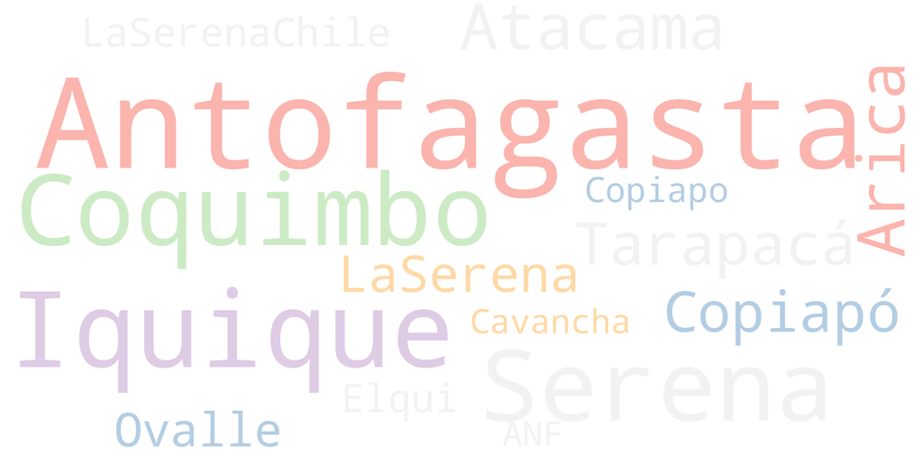

```python
ex_doc = generate_doc_for_cloud(most_north, 20)
generate_cloud(ex_doc)
```

Nube de palabras solo en zona Norte

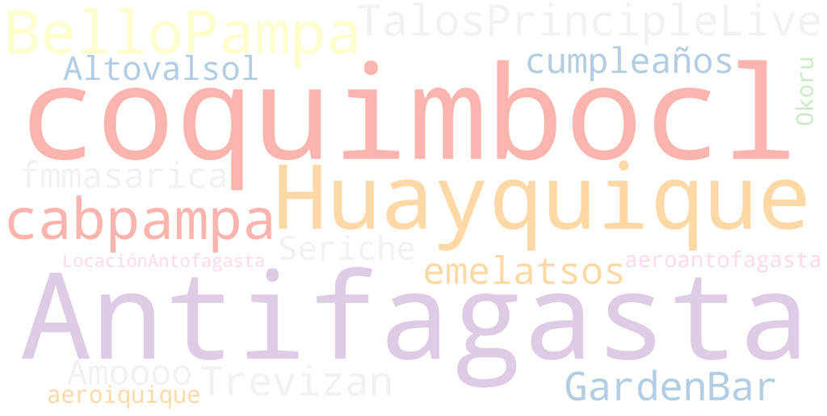

```python
ex_doc = generate_doc_for_cloud(only_north, 20)
generate_cloud(ex_doc)
```

Nube de palabras zona Centro

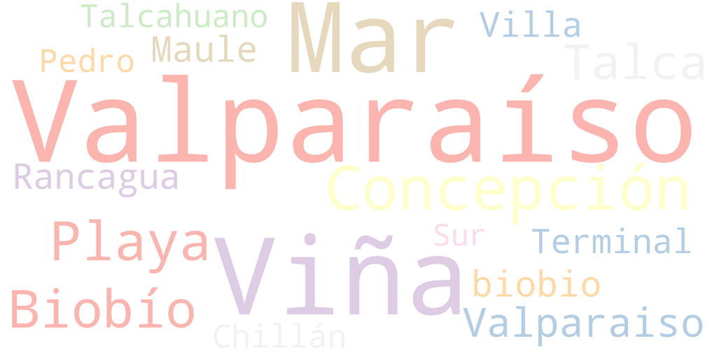

```python
ex_doc = generate_doc_for_cloud(most_center, 20)
generate_cloud(ex_doc)
```

Nube de palabras solo en zona Centro

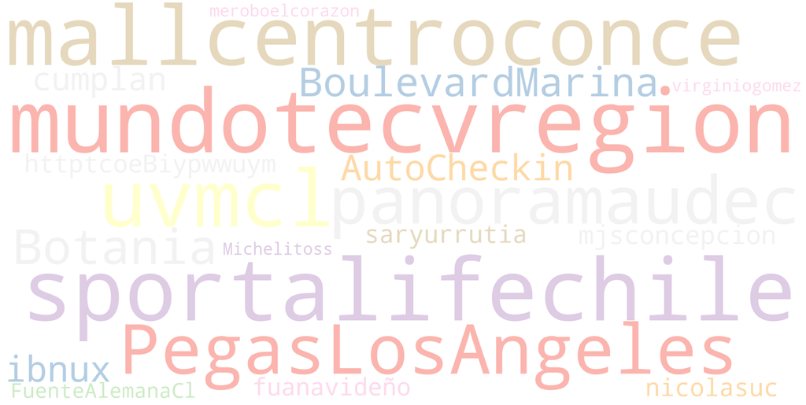

```python
ex_doc = generate_doc_for_cloud(only_center, 20)
generate_cloud(ex_doc)
```

Nube de palabras RM

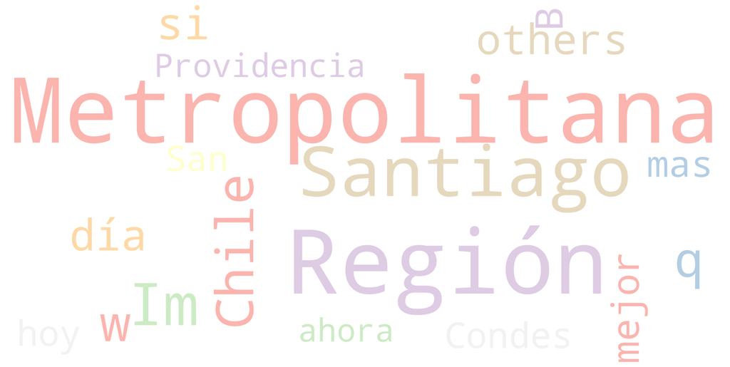

```python
ex_doc = generate_doc_for_cloud(most_rm, 20)
generate_cloud(ex_doc)
```

Nube de palabras solo en RM

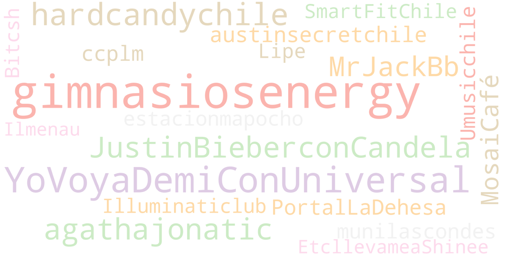

```python
ex_doc = generate_doc_for_cloud(only_rm, 20)
generate_cloud(ex_doc)
```

Nube de palabras zona Sur

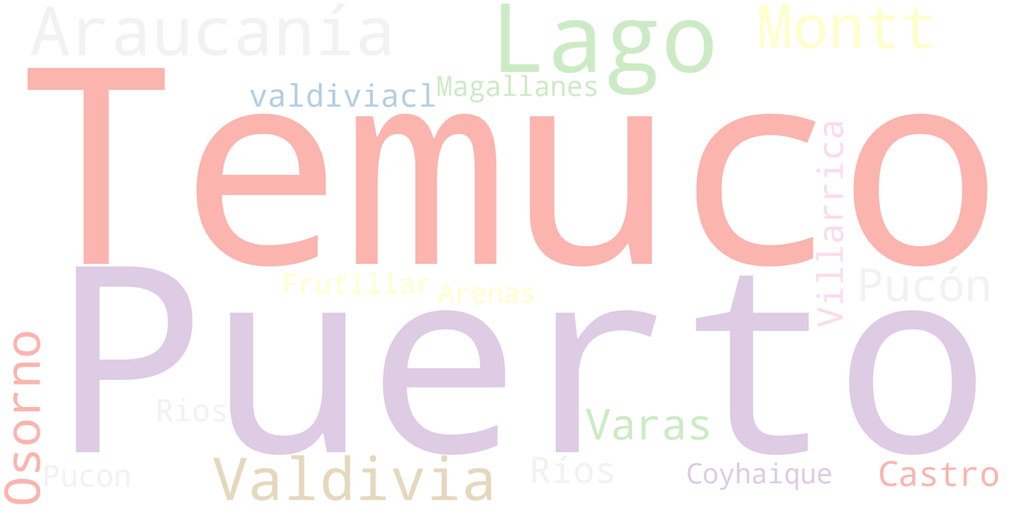

```python
ex_doc = generate_doc_for_cloud(most_south, 20)
generate_cloud(ex_doc)
```

Nube de palabras solo en zona Sur

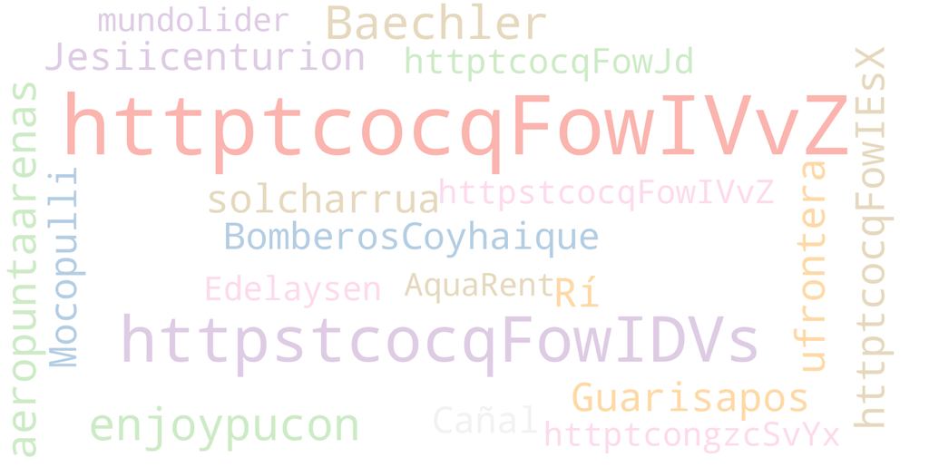

```python
ex_doc = generate_doc_for_cloud(only_south, 20)
generate_cloud(ex_doc)
```

## Conclusión

Con los resultados obtenidos se puede observar que existen algunas palabras que son más representativas de ciertas zonas, así como algunos términos que sólo fueron mencionados exclusivamente en una zona. Con esto se puede responder entonces que sí existen palabras representativas de las distintas zonas. Sin embargo, con respecto a los modismos, con la experimentación realizada no se pudo concluir al respecto, ya que en general las palabras más frecuentes no necesariamente correspondían a este tipo de palabras.